# Text Classification for Amazon Product Reviews

This notebook contains machine learning model implementation with LSTM layer and Embedding for classification text about Amazon Product Reviews, i.e. whether a review is considered as good or bad review. The model gave high accuracy (> 90%) on the training and validation dataset yet the model is overfitted.

```python
import zipfile
import pandas as pd
import nltk
import matplotlib.pyplot as plt
import tensorflow
from nltk.corpus import stopwords
from tensorflow.keras import Sequential
from tensorflow.keras.callbacks import Callback
from tensorflow.keras.layers import Embedding, LSTM, Dense, Dropout
from tensorflow.keras.preprocessing.text import Tokenizer, text_to_word_sequence
from tensorflow.keras.preprocessing.sequence import pad_sequences
from google.colab import files
from sklearn.model_selection import train_test_split
%matplotlib inline
```

### Download File Preparation

```python
# Meng-install Kaggle untuk proses download dataset
!pip install -q kaggle
```

```python
# Tempat untuk melakukan upload Kaggle JSON
files.upload()
```

```python
# Memindahkan Kaggle JSON ke current dir
!mkdir ~/.kaggle
!cp kaggle.json ~/.kaggle/
!chmod 600 ~/.kaggle/kaggle.json
```

```python
# Men-download dataset
!kaggle datasets download -d datafiniti/consumer-reviews-of-amazon-products
```

```
Downloading consumer-reviews-of-amazon-products.zip to /content
 62% 10.0M/16.3M [00:00<00:00, 44.9MB/s]
100% 16.3M/16.3M [00:00<00:00, 64.3MB/s]
```

### Dataset Preparation

I used Amazon Product Reviews dataset for this notebook. The data that will be analyzed is review text and its rating.

```python
# Proses extract zip
file_path = 'consumer-reviews-of-amazon-products.zip'
zip_ref = zipfile.ZipFile(file_path, 'r')
zip_ref.extractall()
zip_ref.close()
```

```python
# Load file
df = pd.read_csv('Datafiniti_Amazon_Consumer_Reviews_of_Amazon_Products_May19.csv')
df.head()
```

|  | id | dateAdded | dateUpdated | name | asins | brand | categories | primaryCategories | imageURLs | keys | ... | reviews.didPurchase | reviews.doRecommend | reviews.id | reviews.numHelpful | reviews.rating | reviews.sourceURLs | reviews.text | reviews.title | reviews.username | sourceURLs |
| --- | --- | --- | --- | --- | --- | --- | --- | --- | --- | --- | --- | --- | --- | --- | --- | --- | --- | --- | --- | --- | --- |
| 0 | AVpgNzjwLJeJML43Kpxn | 2015-10-30T08:59:32Z | 2019-04-25T09:08:16Z | AmazonBasics AAA Performance Alkaline Batterie... | B00QWO9P0O,B00LH3DMUO | Amazonbasics | AA,AAA,Health,Electronics,Health & Household,C... | Health & Beauty | https://images-na.ssl-images-amazon.com/images... | amazonbasics/hl002619,amazonbasicsaaaperforman... | ... | NaN | NaN | NaN | NaN | 3 | https://www.amazon.com/product-reviews/B00QWO9... | I order 3 of them and one of the item is bad q... | ... 3 of them and one of the item is bad quali... | Byger yang | https://www.barcodable.com/upc/841710106442,ht... |
| 1 | AVpgNzjwLJeJML43Kpxn | 2015-10-30T08:59:32Z | 2019-04-25T09:08:16Z | AmazonBasics AAA Performance Alkaline Batterie... | B00QWO9P0O,B00LH3DMUO | Amazonbasics | AA,AAA,Health,Electronics,Health & Household,C... | Health & Beauty | https://images-na.ssl-images-amazon.com/images... | amazonbasics/hl002619,amazonbasicsaaaperforman... | ... | NaN | NaN | NaN | NaN | 4 | https://www.amazon.com/product-reviews/B00QWO9... | Bulk is always the less expensive way to go fo... | ... always the less expensive way to go for pr... | ByMG | https://www.barcodable.com/upc/841710106442,ht... |
| 2 | AVpgNzjwLJeJML43Kpxn | 2015-10-30T08:59:32Z | 2019-04-25T09:08:16Z | AmazonBasics AAA Performance Alkaline Batterie... | B00QWO9P0O,B00LH3DMUO | Amazonbasics | AA,AAA,Health,Electronics,Health & Household,C... | Health & Beauty | https://images-na.ssl-images-amazon.com/images... | amazonbasics/hl002619,amazonbasicsaaaperforman... | ... | NaN | NaN | NaN | NaN | 5 | https://www.amazon.com/product-reviews/B00QWO9... | Well they are not Duracell but for the price i... | ... are not Duracell but for the price i am ha... | BySharon Lambert | https://www.barcodable.com/upc/841710106442,ht... |
| 3 | AVpgNzjwLJeJML43Kpxn | 2015-10-30T08:59:32Z | 2019-04-25T09:08:16Z | AmazonBasics AAA Performance Alkaline Batterie... | B00QWO9P0O,B00LH3DMUO | Amazonbasics | AA,AAA,Health,Electronics,Health & Household,C... | Health & Beauty | https://images-na.ssl-images-amazon.com/images... | amazonbasics/hl002619,amazonbasicsaaaperforman... | ... | NaN | NaN | NaN | NaN | 5 | https://www.amazon.com/product-reviews/B00QWO9... | Seem to work as well as name brand batteries a... | ... as well as name brand batteries at a much ... | Bymark sexson | https://www.barcodable.com/upc/841710106442,ht... |
| 4 | AVpgNzjwLJeJML43Kpxn | 2015-10-30T08:59:32Z | 2019-04-25T09:08:16Z | AmazonBasics AAA Performance Alkaline Batterie... | B00QWO9P0O,B00LH3DMUO | Amazonbasics | AA,AAA,Health,Electronics,Health & Household,C... | Health & Beauty | https://images-na.ssl-images-amazon.com/images... | amazonbasics/hl002619,amazonbasicsaaaperforman... | ... | NaN | NaN | NaN | NaN | 5 | https://www.amazon.com/product-reviews/B00QWO9... | These batteries are very long lasting the pric... | ... batteries are very long lasting the price ... | Bylinda | https://www.barcodable.com/upc/841710106442,ht... |

5 rows × 24 columns

### Data Preprocessing

```python
# Hanya mengambil data review dan rating
data = df.loc[:, ['reviews.text', 'reviews.rating']]
data.head()
```

|  | reviews.text | reviews.rating |
| --- | --- | --- |
| 0 | I order 3 of them and one of the item is bad q... | 3 |
| 1 | Bulk is always the less expensive way to go fo... | 4 |
| 2 | Well they are not Duracell but for the price i... | 5 |
| 3 | Seem to work as well as name brand batteries a... | 5 |
| 4 | These batteries are very long lasting the pric... | 5 |

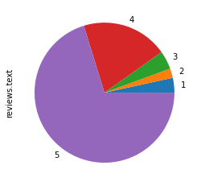

```python
df.groupby('reviews.rating')['reviews.text'].count().plot(kind='pie')
```

From the graph results, it is found that the data is very imbalanced with evidence that the product with a rating of 5 is much greater than the rating with a value of 4 or less. Even a rating with a value of 4 is much greater than a rating with a value of 3 or below. Therefore, upsampling will be carried out with the assumption that:

- Rating 1-2 is a 'bad rating'
- Rating 3 is a 'neutral rating'
- Rating 4-5 is a 'good rating'

Although there are 3 categories, this notebook will only classify 'good' and 'bad' ratings.

```python
def upsampling(rate):
  if rate < 3:
    return 'bad'
  elif rate > 3:
    return 'good'

  return 'neutral'

data['reviews.stat'] = data['reviews.rating'].apply(lambda x: upsampling(x))
```

```python
data.head()
```

|  | reviews.text | reviews.rating | reviews.stat |
| --- | --- | --- | --- |
| 0 | I order 3 of them and one of the item is bad q... | 3 | neutral |
| 1 | Bulk is always the less expensive way to go fo... | 4 | good |
| 2 | Well they are not Duracell but for the price i... | 5 | good |
| 3 | Seem to work as well as name brand batteries a... | 5 | good |
| 4 | These batteries are very long lasting the pric... | 5 | good |

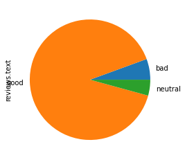

```python
data.groupby('reviews.stat')['reviews.text'].count().plot(kind='pie')
```

From graph above, it can be seen that the results of the upsampling is still very imbalanced yet relatively better than before. Therefore, for training and evaluating the model, the sample that will be taken for a 'good rating' is only 1600.

```python
# Memisahkan data
bad_data = data[data['reviews.stat'] == 'bad']
good_data = data[data['reviews.stat'] == 'good'].sample(n=1600, replace=True)
final_data = pd.concat([good_data, bad_data], axis=0)
```

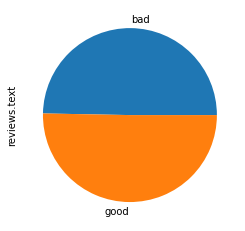

```python
final_data.groupby('reviews.stat')['reviews.text'].count().plot(kind='pie')
```

In the graph above, it can be seen that the data set is better because there is a balance between 'good' and 'bad' data.

```python
# Melakukan print terkait dengan informasi dataset
# dan jumlah data 'good' and 'bad'
print("Informasi terkait dengan data:\n")
print(final_data.info())
print()
print("Sebaran data:\n", final_data.groupby('reviews.stat')['reviews.text'].count())
```

[output not shown]

```python
# Encoding
# Melakukan perubahan string menjadi int
final_data['reviews.stat.label'] = [0 if stat == 'bad' else 1 for stat in final_data['reviews.stat']]
```

Removing stop words because the existence of these stop words do not have much influence on the model

```python
# Stop word removal
nltk.download('stopwords')
stopwords_list_en = stopwords.words('english')

def remove_stop_words(word_seq):
  new_sntc = " ".join(filter(lambda word: word not in stopwords_list_en, word_seq))

  return new_sntc

final_data['text_excl_swords'] = final_data['reviews.text'].apply(lambda words: remove_stop_words(text_to_word_sequence(words)))
final_data.head()
```

|  | reviews.text | reviews.rating | reviews.stat | reviews.stat.label | text_excl_swords |
| --- | --- | --- | --- | --- | --- |
| 10856 | Great price. Work as expected. | 5 | good | 1 | great price work expected |
| 9889 | Super great deal. | 5 | good | 1 | super great deal |
| 112 | of course these are no energizer bunny batteri... | 5 | good | 1 | course energizer bunny batteries price amount ... |
| 1418 | Batteries work (and last) as expected for a gr... | 5 | good | 1 | batteries work last expected great price |
| 24377 | I love this solutions for my kids. I gave it a... | 4 | good | 1 | love solutions kids gave four star rating orde... |

```python
# Memisahkan data feature dan label
X = final_data['text_excl_swords'].values
y = final_data['reviews.stat.label'].values
```

```python
# Melakukan split train-test data
X_train, X_test, y_train, y_test = train_test_split(X, y, test_size=0.2)
```

```python
# Proses tokenisasi
tokenizer = Tokenizer(num_words=5000, oov_token='x')
tokenizer.fit_on_texts(X_train)
tokenizer.fit_on_texts(X_test)

X_train_seq = tokenizer.texts_to_sequences(X_train)
X_test_seq = tokenizer.texts_to_sequences(X_test)

X_train_pad = pad_sequences(X_train_seq)
X_test_pad = pad_sequences(X_test_seq)
```

```python
# Pembuatan model
model = Sequential([
    Embedding(input_dim=5000, output_dim=32),
    LSTM(64),
    Dense(64, activation='relu'),
    Dropout(0.6),
    Dense(32, activation='relu'),
    Dropout(0.4),
    Dense(16, activation='relu'),
    Dropout(0.25),
    Dense(1, activation='sigmoid')
])
```

```python
model.summary()
```

```
Model: "sequential"
_________________________________________________________________
 Layer (type)                Output Shape              Param #
=================================================================
 embedding (Embedding)       (None, None, 32)          160000

 lstm (LSTM)                 (None, 64)                24832

 dense (Dense)               (None, 64)                4160

 dropout (Dropout)           (None, 64)                0

 dense_1 (Dense)             (None, 32)                2080

 dropout_1 (Dropout)         (None, 32)                0

 dense_2 (Dense)             (None, 16)                528

 dropout_2 (Dropout)         (None, 16)                0

 dense_3 (Dense)             (None, 1)                 17

=================================================================
Total params: 191,617
Trainable params: 191,617
Non-trainable params: 0
_________________________________________________________________
```

```python
model.compile(loss='binary_crossentropy', optimizer=tensorflow.keras.optimizers.Adam(learning_rate=0.0008), metrics=['accuracy'])
```

```python
ep = 0
counter = 0

# Membuat fungsi callback untuk early stopping
# dengan kriteria apabila telah 5 kali mencapai nilai akurasi train dan validasi lebih dari 0.9
class ModelCallback(Callback):
  def on_epoch_end(self, epoch, logs=None):
    global counter
    global ep

    curr_train_acc = round(logs['accuracy'], 2)
    curr_val_acc = round(logs['val_accuracy'], 2)
    ep += 1

    if curr_train_acc >= 0.90 and curr_val_acc >= 0.90:
      counter += 1
      if counter == 5:
        print("Training stopped at epoch of {} with train accuracy: {} and validation accuracy: {}".format(epoch+1, curr_train_acc, curr_val_acc))
        self.model.stop_training = True
```

```python
%%time
history = model.fit(X_train_pad,
                    y_train,
                    epochs=25,
                    validation_data=(X_test_pad, y_test),
                    callbacks=[ModelCallback()],
                    verbose=2)
```

```
80/80 - 17s - loss: 0.6882 - accuracy: 0.5330 - val_loss: 0.6424 - val_accuracy: 0.7143 - 17s/epoch - 207ms/step
80/80 - 11s - loss: 0.5118 - accuracy: 0.7960 - val_loss: 0.3383 - val_accuracy: 0.8807 - 11s/epoch - 137ms/step
80/80 - 11s - loss: 0.2431 - accuracy: 0.9214 - val_loss: 0.3390 - val_accuracy: 0.8713 - 11s/epoch - 137ms/step
80/80 - 11s - loss: 0.1575 - accuracy: 0.9509 - val_loss: 0.3075 - val_accuracy: 0.8791 - 11s/epoch - 138ms/step
80/80 - 11s - loss: 0.1180 - accuracy: 0.9623 - val_loss: 0.3314 - val_accuracy: 0.9058 - 11s/epoch - 144ms/step
80/80 - 11s - loss: 0.0782 - accuracy: 0.9815 - val_loss: 0.3583 - val_accuracy: 0.9074 - 11s/epoch - 139ms/step
80/80 - 11s - loss: 0.0530 - accuracy: 0.9862 - val_loss: 0.4882 - val_accuracy: 0.9027 - 11s/epoch - 138ms/step
80/80 - 11s - loss: 0.0487 - accuracy: 0.9886 - val_loss: 0.4950 - val_accuracy: 0.8995 - 11s/epoch - 138ms/step
Training stopped at epoch of 9 with train accuracy: 0.99 and validation accuracy: 0.91
80/80 - 11s - loss: 0.0430 - accuracy: 0.9878 - val_loss: 0.5554 - val_accuracy: 0.9058 - 11s/epoch - 143ms/step
CPU times: user 2min 49s, sys: 9.91 s, total: 2min 59s
Wall time: 1min 45s
```

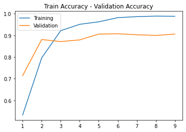

```python
plt.plot(range(1,ep+1), history.history['accuracy'], label='Training')
plt.plot(range(1,ep+1), history.history['val_accuracy'], label='Validation')
plt.title("Train Accuracy - Validation Accuracy")
plt.legend()
plt.show()
```

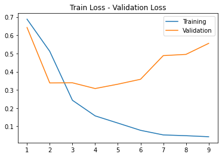

```python
plt.clf()

plt.plot(range(1,ep+1), history.history['loss'], label='Training')
plt.plot(range(1,ep+1), history.history['val_loss'], label='Validation')
plt.title("Train Loss - Validation Loss")
plt.legend()
plt.show()
```